# Dynamic Documents For Your Research Workflow

Fernando Hoces de la Guardia BITSS - Slides at https://tinyurl.com/y86d6emu

RT2 Amsterdam, April 2018

# Dynamic Documents For Computational Reproducibility

## Dynamic Documents For Computational Reproducibility

- Based on principles of *literate programming* aims at combining code and paper in one single document
- Best framework to achieve the holy grail of **one-click reproducible workflow**
- Best two current implementations: `RMarkdown (R)` & `Jupyter (Python)`. `Stata` is catching up (dyndocs release [here](https://www.stata.com/new-in-stata/markdown/) and reviews [here](http://data.princeton.edu/stata/markdown/markstat.htm) and [here](https://www.bitss.org/2017/09/05/review-of-statas-dyndoc/))

## Currently code and narrative components live in separate universes

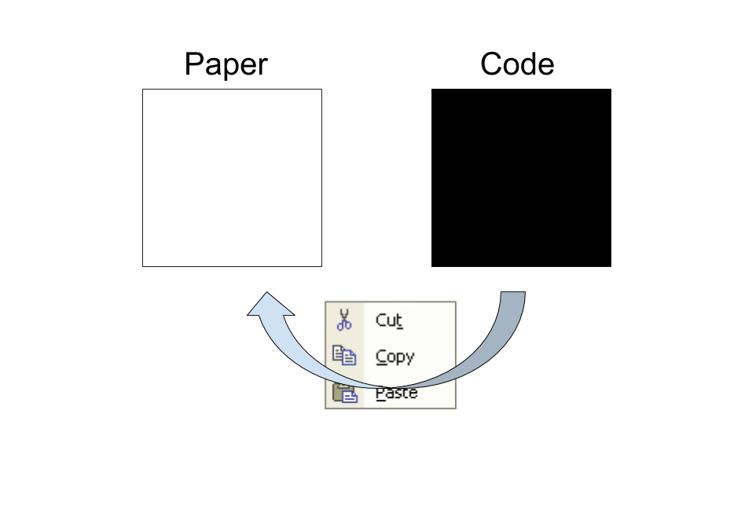

## Dynamic Documents: integrate the two universes!

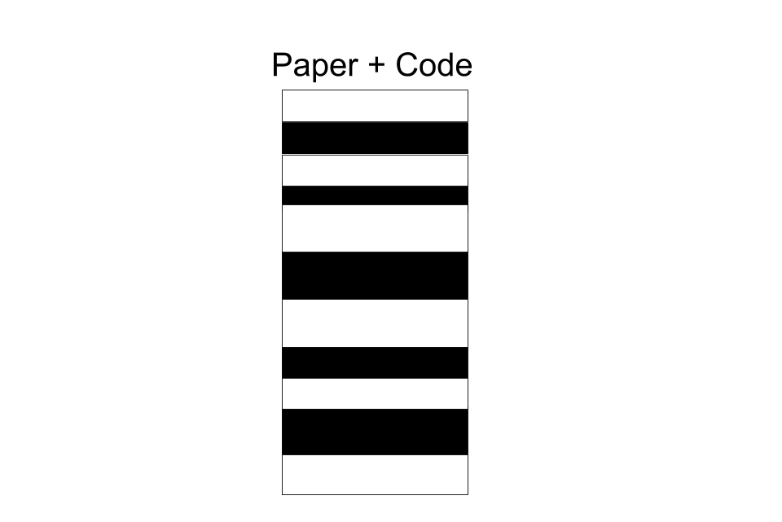

## Dynamic Documents: A Recipe

- 1 simple language that can combine text and code: `Markdown`
- 1 statistical package to do the analysis (`R`, `Python`, `3S's?`)
- 1 machinery to combine analysis and text to create a single output: `Pandoc`
- [Optional-but-not-really] 1 program to bring all the elements together: RStudio/RMarkdown, Jupyter

## Markdown laguange/syntax in 60 seconds

[figure not shown]

# One Type of Dynamic Document: R Markdown

## For our excercise: R Markdown

- `R`: **open source** programming language design for statistical analysis.
- RStudio: free software that provides and Integrated Development Environment (IDE)
- RStudio combines all together: R + Markdown + Pandoc to produce multiple outputs

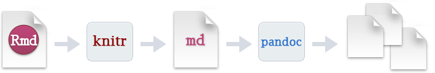

## R Markdown

[figure not shown]

## Basic Structure

- A header
- Text
- Code: inline and chunks

## Basic Structure: Header

```r
---
title: "Sample Paper"
author: "Fernando Hoces de la Guardia"
output: html_document
---
```

## Basic Structure: Body of Text

```r
---
header
---
```

This is where you write your paper. Nothing much to add. You can check Markdown [syntax here](https://www.rstudio.com/wp-content/uploads/2015/02/rmarkdown-cheatsheet.pdf). And it can use can type equations using LaTex syntax!

## Basic Structure: Code Chunks and Inline

```r
---
header
---
```

Body of text.

To begin a piece of code (“code chunk”). Enclose them in the following expression (Ctrl/Cmd + shift/optn + i)

````
```{r, eval=TRUE}
here goes the code
```
````

To write inline use only one Backtick to open followed by an “r”" and one to close `` `r 1+1` `` in the output.

# Practical Excercise #1

## Hands-on excercise: the birthday problem!

As an illustration lets write a report using the participants in this workshop to illustrate the famous [birthday problem](https://en.wikipedia.org/wiki/Birthday_problem).

> What is the probability that at least two people this room share the same birthday?

> Is it something like $\frac{1}{365} \times N =$ 0.074?

## Create a new RMarkdown File

1 - In RStudio: `File-> New File -> RMarkdown...`  
2 - Name it, and save it.  
3 - Review/edit the header, and delete all the default body of text except for one code chunk.  
4 - In that chunk define a seed (`set.seed(1234)` and number of people in the room (`n.pers = ?`).  
5 - Below the first chunk, write down a title (using `#`) and a brief description.

## The birthday problem: the math

Actually the math says otherwise:
$$\begin{align}
1 - p(n) &= 1 \times \left(1-\frac{1}{365}\right) \times \left(1-\frac{2}{365}\right) \times \cdots \times \left(1-\frac{n-1}{365}\right) \nonumber \\ &= \frac{ 365 \times 364 \times \cdots \times (365-n+1) }{ 365^n } \nonumber \\ &= \frac{ 365! }{ 365^n (365-n)!} = \frac{n!\cdot\binom{365}{n}}{365^n}\\
p(n= 27) &= 0.627 \nonumber
\end{align}$$

## Code for the math (`/2-dynamicdocs/first_dd_solution.Rmd`)

Not relevant to look at: just copy and paste lines 23-30 from the solutions into your dynamic document.

```r
\begin{align}
 1 - \bar p(n) &= 1 \times \left(1-\frac{1}{365}
                                 \right)
 \times ...
 A lot of equations using LateX syntax!
\end{align}
```

## Don’t like math? Let’s run a simple simulation!

1 - Simulate 10,000 rooms with $n = 27$ random birthdays, and store the results in matrix where each row represents a room.  
2 - For each room (row) compute the number of unique birthdays.  
3 - Compute the average number of times a room has 27 unique birthdays, across 10,000 simulations, and report the complement.

## Code for the simulation (`/first_dd_solution.Rmd`)

```r
birthday.prob = function(n.pers, n.sims) {
  # simulate birthdays
  birthdays = matrix(round(runif(n.pers * n.sims,
                                 1, 365)),
                      nrow = n.sims, ncol = n.pers)
  # for each room (row) get unique birthdays
  unique.birthdays = apply(birthdays, 1,
                           function(x)
                             length(unique(x)) )
  # Indicator with 1 if all are unique birthdays
  all.different = 1 * (unique.birthdays==n.pers)
  # Compute average time all have different birthdays
  result = 1 - mean(all.different)
return(result)
}
n.pers.param = 27; n.sims.param = 1e4
birthday.prob(n.pers.param,n.sims.param)
```

```
## [1] 0.6286
```

# Practical Excercise #2

## Hands-on excercise #2: Mostly Harmless Econometrics!

There is a [fantastic Github](https://github.com/vikjam/mostly-harmless-replication) repo that is reproducing results from MHE

Lets use the of examples Figure [5.2.4](https://github.com/vikjam/mostly-harmless-replication/blob/master/05%20Fixed%20Effects%2C%20DD%20and%20Panel%20Data/Figure%205-2-4.r) to show how dynamic docs can be used in data analysis.

# Practical Excercise #3

## Hands-on excercise #3: Stata and TIER

1- Go to github.com and search `dyndoc tier` or click here: github.com/dvorakt/TIER_exercises.  
2- Download or clone the repo.  
3- Unzip it.  
4- Open Stata (15) and type `dyndoc filepath/dyndoc_debt_growth/debt and growth stata dyndoc.do", replace` 5- Go to the folder and click in `debt and growth stata dyndoc.html`

# Final Remarks & More Resources

## Final Remarks & More Resources

- With DD we can achieve a one-click reproducible workflow.
- This is particularly helpful to understand/present results that are hard to digest.
- Stata just develop an internal version of DD for v15. [Review Here](https://www.bitss.org/2017/09/05/review-of-statas-dyndoc/)
- More great examples in the workshop repo (`4-Moredynamicdocs`)
- Want to learn more: [great free books](https://bookdown.org/) (can you guess how they were written?)